# Mini Project 1 Problem 2: K-means Clustering

### Name: Fei Yin

### PID: A15555426

In this problem, we will build a K-means clustering algorithm to cluster the hand-written digits into a certain number of clusters. In effect, this is an unsupervised machine learning algorithm. After building the algorithm, we will test its performance on different number of clusters. Also, since the algorithm starts by randomly assigning data vectors to clusters, the clustering converges to different final states, so we will repeat each experiment multiple times.

**Important Note: To speed up some processes in this part of the project, multiprocessing is used. To ensure memory leak does not happen, make sure to run `jupyter notebook --NotebookApp.max_buffer_size=8589934592` in terminal to re-open Jupyter Notebook. This sets the memory limit of Jupyter Notebook to 8 GB. However, if a system's usable memory is less than 8GB, potential freeze could happen. In that case, try reducing the pool count by changing the `multiprocessing_pool_count` variable, located in the code cell below, to a smaller number. This is also noted in the README file.**

```python
multiprocessing_pool_count = 8
```

```python
import sys
import time
import tqdm
import numpy as np
import matplotlib.pyplot as plt
import multiprocessing.pool as mpp
from scipy.io import loadmat
```

```python
## Load data from mnist.mat
mnist = loadmat('mnist.mat')
train_x = mnist['trainX']
train_y = mnist['trainY']
test_x = mnist['testX']
test_y = mnist['testY']
```

```python
## Verify shapes of training and test data
print(train_x.shape)
print(train_y.shape)
print(test_x.shape)
print(test_y.shape)
```

```
(60000, 784)
(1, 60000)
(10000, 784)
(1, 10000)
```

The `kmeans` function below implements the K-means clustering algorithm. It initializes by randomly assigning `data_vectors` into K (`cluster_count`) clusters while also initializing other return variables. After initialization, iterations start. During each iteration, three thing happen: 1) group representative vectors (`grvs`) are calculated to be the centroid of each of their corresponding clusters, 2) each data vector is reassigned to the closest group representative vector, and 3) `j_clust` is recalculated. The iteration stops when the difference between consecutive `j_clust` is less than 10. The function returns the final group assignment indices (`gais`), the final group representative vectors (`grvs`), and a list of all the `j_clust` values after every iteration (`j_clusts`).

```python
def kmeans(data_vectors, cluster_count):
    """Cluster the input vectors with K-means until difference between consecutive j clust is less than 10.

    Keyword arguments:
    data_vectors -- the input vectors to cluster
    cluster_count -- number of clusters to form

    Returns:
    gais -- group assignment indices after the final iteration
    grvs -- group representative vectors after the final iteration
    j_clusts -- a list of j_clust values after every iteration
    """

    ## Seed random such that every process in multiprocessing has a different random sequence
    np.random.seed()

    ## Initialize by assigning each data vector to a random cluster
    gais = np.random.randint(cluster_count, size=data_vectors.shape[0])
    grvs = np.zeros((cluster_count, data_vectors.shape[1]))
    j_clusts = []

    j_clust_old = float(sys.maxsize)
    j_clust = float(sys.maxsize) / 2

    ## Terminate when J clust difference between iterations is less than 10
    while (j_clust_old - j_clust) > 10:

        j_clust_old = j_clust

        ## Assign each group representative vector its corresponding cluster's centroid
        for i in range(cluster_count):
            grvs[i] = np.mean(data_vectors[gais == i], axis=0)

        ## Assign each data vector to the cluster with the closest group representative vector
        for i, data_vector in enumerate(data_vectors):
            min_distance = float('inf')
            closest_cluster_index = 0

            for j, grv in enumerate(grvs):
                distance = np.subtract(data_vector, grv).T @ np.subtract(data_vector, grv)

                if distance < min_distance:
                    min_distance = distance
                    closest_cluster_index = j

            gais[i] = closest_cluster_index
            j_clust += min_distance

        ## Calculate J clust
        j_clust /= data_vectors.shape[0]
        j_clusts.append(j_clust)
        #print('j_clust difference: ', j_clust_old - j_clust)

    #print('kmeans run completed')
    return gais, grvs, j_clusts
```

```python
def findMinMaxJclustIndices(clustering_results):
    """Find the indices of the two runs resulting in the largest and smallest j_clust upon convergence.

    Keyword arguments:
    clustering_results -- a list of clustering results
                          Each clustering result is a tuple of gais, grvs, and j_clusts.
                          Details of these three variables can be found in the docstring of the kmeans function.

    Returns:
    max_j_clust_index -- index of the run resulting in the largest j_clust upon convergence
    min_j_clust_index -- index of the run resulting in the smallest j_clust upon convergence
    """

    max_j_clust = 0.0
    min_j_clust = float(sys.maxsize)
    max_j_clust_index = 0
    min_j_clust_index = 0

    for i, result in enumerate(clustering_results):
        if result[2][-1] > max_j_clust:
            max_j_clust = result[2][-1]
            max_j_clust_index = i
        if result[2][-1] < min_j_clust:
            min_j_clust = result[2][-1]
            min_j_clust_index = i

    return max_j_clust_index, min_j_clust_index
```

```python
def findTenNearest(data_vectors, grv):
    """Find 10 nearest data vectors with repect to the group representative vector given.

    Keyword arguments:
    data_vectors -- a set of input vectors
    grv -- a group representative vector

    Returns:
    ten_nearest_vectors -- 10 data vectors that are nearest to the group representative vector
    """

    ten_nearest_vectors = np.zeros((10, data_vectors.shape[1]))
    ten_nearest_distances = np.ones((10, 1)) * np.inf

    for data_vector in data_vectors:
        distance = np.subtract(data_vector, grv).T @ np.subtract(data_vector, grv)

        for i in range(10):
            if distance < ten_nearest_distances[i]:
                ten_nearest_distances[i] = distance
                ten_nearest_vectors[i] = data_vector
                break

    return ten_nearest_vectors
```

```python
## istarmap function comes from:
##   https://stackoverflow.com/questions/57354700/starmap-combined-with-tqdm
def istarmap(self, func, iterable, chunksize=1):
    """starmap-version of imap"""

    if self._state != mpp.RUN:
        raise ValueError("Pool not running")

    if chunksize < 1:
        raise ValueError(
            "Chunksize must be 1+, not {0:n}".format(
                chunksize))

    task_batches = mpp.Pool._get_tasks(func, iterable, chunksize)
    result = mpp.IMapIterator(self._cache)
    self._taskqueue.put(
        (
            self._guarded_task_generation(result._job,
                                          mpp.starmapstar,
                                          task_batches),
            result._set_length
        ))
    return (item for chunk in result for item in chunk)

mpp.Pool.istarmap = istarmap
```

## Single-run Tests

The `kmeans` function is run once each for K = 20, 10, and 5 to test its correctness and time consumption.

```python
#start_time = time.time()
#gais, grvs, j_clust = kmeans(train_x, 20)
#print("--- %s seconds ---" % (time.time() - start_time))
```

```python
#start_time = time.time()
#gais, grvs, j_clust = kmeans(train_x, 10)
#print("--- %s seconds ---" % (time.time() - start_time))
```

```python
#start_time = time.time()
#gais, grvs, j_clust = kmeans(train_x, 5)
#print("--- %s seconds ---" % (time.time() - start_time))
```

## Test 1: K = 20, P = 30

For the first test, `kmeans` is run 30 times, where each run clusters the data vectors into 20 clusters.

```python
K = 20
P = 30

## Code for tracking time consumption comes from:
##   https://stackoverflow.com/questions/1557571/how-do-i-get-time-of-a-python-programs-execution
start_time = time.time()
t1_results = []

## Code for using tqdm with istarmap comes from:
##   https://stackoverflow.com/questions/57354700/starmap-combined-with-tqdm
with mpp.Pool(multiprocessing_pool_count) as pool:
    arguments = [(train_x, K) for i in range(P)]
    for result in tqdm.tqdm(pool.istarmap(kmeans, arguments), total=len(arguments)):
        t1_results.append(result)

print("--- %s seconds ---" % (time.time() - start_time))
```

```
--- 1520.972326517105 seconds ---
```

```python
## Find the indices of the two runs that produce the largest and smallest j_clust upon convergence
t1_max_j_clust_index, t1_min_j_clust_index = findMinMaxJclustIndices(t1_results)
```

### Plotting `j_clusts` as a function of the number of iterations

**Note:** The first two `j_clust` values for each run are not plotted because they are abnormally large due to `j_clust` being initialized to `float(sys.maxsize) / 2` in `kmeans`.

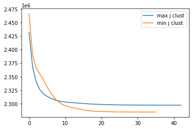

```python
plt.plot(t1_results[t1_max_j_clust_index][2][2:], label='max j clust')
plt.plot(t1_results[t1_min_j_clust_index][2][2:], label='min j clust')
plt.legend()
plt.show()
```

The plot above shows the two sets of `j_clusts` as a function of number of iterations. The last `j_clust` in each of the two sets of `j_clusts` corresponds to the largest and smallest `j_clust` values upon convergence. The difference between those values can clearly be seen on the plot. Within my multiple trials, I have seen the two curves taking slightly different shapes. For example, one curve could end earlier than another, or the two curves could cross path at some point. However, the variations in their paths do not seem to be directly related to their final values. And, reasonably, all of the `j_clusts` vs. number of iterations curves roughly follow logarithmic decaying paths.

### Visualizing the K group representatives as images

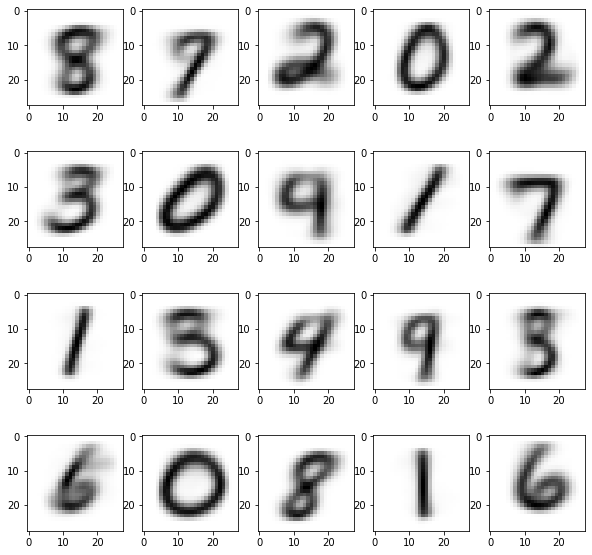

```python
## Image-grid function from:
##   https://matplotlib.org/3.1.0/gallery/subplots_axes_and_figures/subplots_demo.html
fig, axs = plt.subplots(4, 5, figsize=(10, 10))
t1_max_j_clust_grvs = t1_results[t1_max_j_clust_index][1]

for i in range(4):
    for j in range(5):
        axs[i, j].imshow(t1_max_j_clust_grvs[i * 5 + j, :].reshape(28, 28), cmap='binary')
```

The images above show all 20 of the the group representatives from the run with the largest `j_clust` upon convergence. The images are mostly recognizable as digits. However, there are several cases where 7 and 9, 4 and 9, or 8 and 3 are mixed together.

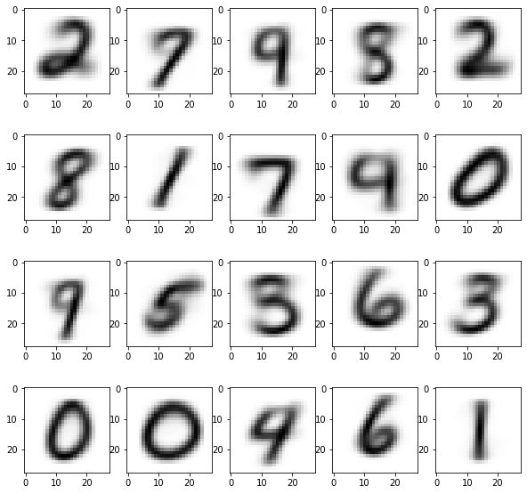

```python
fig, axs = plt.subplots(4, 5, figsize=(10, 10))
t1_min_j_clust_grvs = t1_results[t1_min_j_clust_index][1]

for i in range(4):
    for j in range(5):
        axs[i, j].imshow(t1_min_j_clust_grvs[i * 5 + j, :].reshape(28, 28), cmap='binary')
```

The images above show all 20 of the the group representatives from the run with the smallest `j_clust` upon convergence. The digits with ambiguity still exists and are similar to those in the run with the largest `j_clust` upon convergence. However, the degree of confusion might have slightly decreased as each image seems to be representing one single digit more obviously.

### 10 nearest data points to each of the K group representatives

To evaluate the performance of `kmeans`, we want to understand how well each group representative represents its cluster. To do that, we pick 10 nearest data vectors around each group representative and manually record whether they are misclassified or not.

To conveniently compare each group representative with the 10 nearest data vectors around it, we display them as images side by side, creating an image grid. We distinguish group representatives from data vectors by setting the **group representatives to red-scale** and the **data vectors to gray-scale**.

In an image grid, each row starts with a group representative on the left, followed by 10 nearest data vectors around it. Below each image grid, a table mimicking the format of the image grid is manually created. To record the number of misclassified images for each group representative, one more column is added to the table.

Since we have 20 group representatives representing 20 clusters here, we pick 200 data vectors for the maximum `j_clust` case and 200 data vectors for the minimum `j_clust` case.

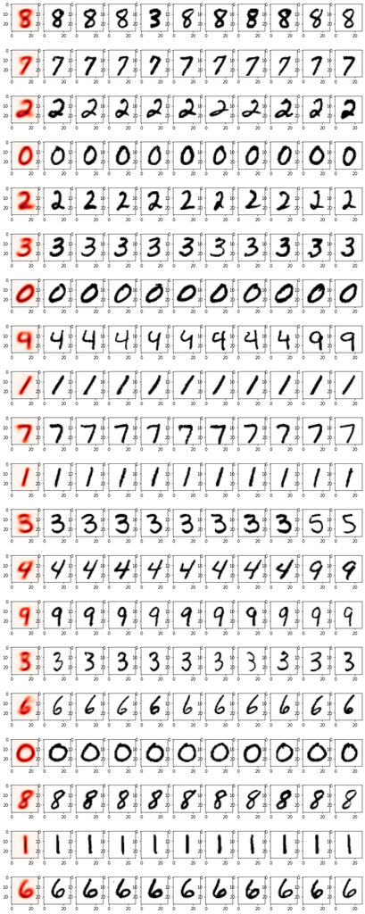

```python
fig, axs = plt.subplots(20, 11, figsize=(15, 40))

for i, grv in enumerate(t1_max_j_clust_grvs):
    axs[i, 0].imshow(grv.reshape(28, 28), cmap='Reds')

    ten_nearest_vectors = findTenNearest(train_x, grv)

    for j, nearest_vector in enumerate(ten_nearest_vectors):
        axs[i, j + 1].imshow(nearest_vector.reshape(28, 28), cmap='binary')
```

| GRVS | NDV1 | NDV2 | NDV3 | NDV4 | NDV5 | NDV6 | NDV7 | NDV8 | NDV9 | NDV10 | Misclassified count |
| --- | --- | --- | --- | --- | --- | --- | --- | --- | --- | --- | --- |
| 8 | 8 | 8 | 8 | 3 | 8 | 8 | 8 | 8 | 8 | 8 | 1 |
| 7 | 7 | 7 | 7 | 7 | 7 | 7 | 7 | 7 | 7 | 7 | 0 |
| 2 | 2 | 2 | 2 | 2 | 2 | 2 | 2 | 2 | 2 | 2 | 0 |
| 0 | 0 | 0 | 0 | 0 | 0 | 0 | 0 | 0 | 0 | 0 | 0 |
| 2 | 2 | 2 | 2 | 2 | 2 | 2 | 2 | 2 | 2 | 2 | 0 |
| 3 | 3 | 3 | 3 | 3 | 3 | 3 | 3 | 3 | 3 | 3 | 0 |
| 0 | 0 | 0 | 0 | 0 | 0 | 0 | 0 | 0 | 0 | 0 | 0 |
| 9 | 4 | 4 | 4 | 4 | 4 | 4 | 4 | 4 | 9 | 9 | 8 |
| 1 | 1 | 1 | 1 | 1 | 1 | 1 | 1 | 1 | 1 | 1 | 0 |
| 7 | 7 | 7 | 7 | 7 | 7 | 7 | 7 | 7 | 7 | 7 | 0 |
| 1 | 1 | 1 | 1 | 1 | 1 | 1 | 1 | 1 | 1 | 1 | 0 |
| 3 | 3 | 3 | 3 | 3 | 3 | 3 | 3 | 3 | 5 | 5 | 2 |
| 4 | 4 | 4 | 4 | 4 | 4 | 4 | 4 | 4 | 9 | 9 | 2 |
| 9 | 9 | 9 | 9 | 9 | 9 | 9 | 9 | 9 | 9 | 9 | 0 |
| 3 | 3 | 3 | 3 | 3 | 3 | 3 | 3 | 3 | 3 | 3 | 0 |
| 6 | 6 | 6 | 6 | 6 | 6 | 6 | 6 | 6 | 6 | 6 | 0 |
| 0 | 0 | 0 | 0 | 0 | 0 | 0 | 0 | 0 | 0 | 0 | 0 |
| 8 | 8 | 8 | 8 | 8 | 8 | 8 | 8 | 8 | 8 | 8 | 0 |
| 1 | 1 | 1 | 1 | 1 | 1 | 1 | 1 | 1 | 1 | 1 | 0 |
| 6 | 6 | 6 | 6 | 6 | 6 | 6 | 6 | 6 | 6 | 6 | 0 |

From the table above, we can calculate the error rate of the K = 20 run with the largest `j_clust` upon convergence to be **(1 + 8 + 2 + 2) / 200 = 6.5%**

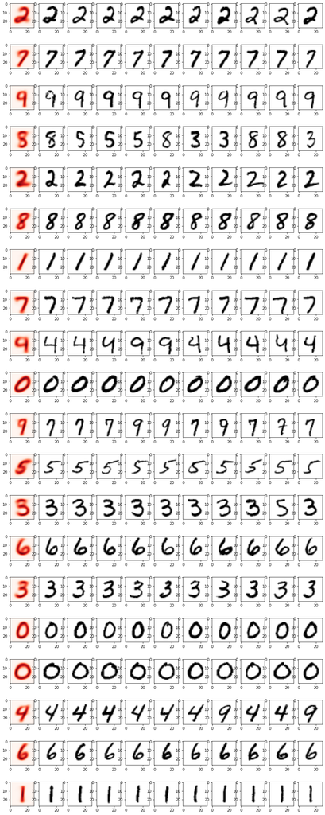

```python
fig, axs = plt.subplots(20, 11, figsize=(15, 40))

for i, grv in enumerate(t1_min_j_clust_grvs):
    axs[i, 0].imshow(grv.reshape(28, 28), cmap='Reds')

    ten_nearest_vectors = findTenNearest(train_x, grv)

    for j, nearest_vector in enumerate(ten_nearest_vectors):
        axs[i, j + 1].imshow(nearest_vector.reshape(28, 28), cmap='binary')
```

| GRVS | NDV1 | NDV2 | NDV3 | NDV4 | NDV5 | NDV6 | NDV7 | NDV8 | NDV9 | NDV10 | Misclassified count |
| --- | --- | --- | --- | --- | --- | --- | --- | --- | --- | --- | --- |
| 2 | 2 | 2 | 2 | 2 | 2 | 2 | 2 | 2 | 2 | 2 | 0 |
| 7 | 7 | 7 | 7 | 7 | 7 | 7 | 7 | 7 | 7 | 7 | 0 |
| 9 | 9 | 9 | 9 | 9 | 9 | 9 | 9 | 9 | 9 | 9 | 0 |
| 8 | 8 | 5 | 5 | 5 | 8 | 3 | 3 | 8 | 8 | 3 | 6 |
| 2 | 2 | 2 | 2 | 2 | 2 | 2 | 2 | 2 | 2 | 2 | 0 |
| 8 | 8 | 8 | 8 | 8 | 8 | 8 | 8 | 8 | 8 | 8 | 0 |
| 1 | 1 | 1 | 1 | 1 | 1 | 1 | 1 | 1 | 1 | 1 | 0 |
| 7 | 7 | 7 | 7 | 7 | 7 | 7 | 7 | 7 | 7 | 7 | 0 |
| 9 | 4 | 4 | 4 | 9 | 9 | 4 | 4 | 4 | 4 | 4 | 8 |
| 0 | 0 | 0 | 0 | 0 | 0 | 0 | 0 | 0 | 0 | 0 | 0 |
| 9 | 7 | 7 | 7 | 9 | 9 | 7 | 9 | 7 | 7 | 7 | 7 |
| 5 | 5 | 5 | 5 | 5 | 5 | 5 | 5 | 5 | 5 | 5 | 0 |
| 3 | 3 | 3 | 3 | 3 | 3 | 3 | 3 | 3 | 5 | 3 | 1 |
| 6 | 6 | 6 | 6 | 6 | 6 | 6 | 6 | 6 | 6 | 6 | 0 |
| 3 | 3 | 3 | 3 | 3 | 3 | 3 | 3 | 3 | 3 | 3 | 0 |
| 0 | 0 | 0 | 0 | 0 | 0 | 0 | 0 | 0 | 0 | 0 | 0 |
| 0 | 0 | 0 | 0 | 0 | 0 | 0 | 0 | 0 | 0 | 0 | 0 |
| 4 | 4 | 4 | 4 | 4 | 4 | 4 | 9 | 4 | 4 | 9 | 2 |
| 6 | 6 | 6 | 6 | 6 | 6 | 6 | 6 | 6 | 6 | 6 | 0 |
| 1 | 1 | 1 | 1 | 1 | 1 | 1 | 1 | 1 | 1 | 1 | 0 |

From the table above, we can calculate the error rate of the K = 20 run with the smallest `j_clust` upon convergence to be **(6 + 8 + 7 + 1 + 2) / 200 = 12%**. The error rate of this run is higher than that of the run with the largest `j_clust` upon convergence, which is counter-intuitive. However, this can be explained if we account for the subjective aspect involved in calculating the error rate. That is, in calculating the error rate, the digits that the group representatives represent are determined by me based on what I know about digits. However, what I know about digits is not involved in the program's learning process. So its interpretation of the group representatives can be different from my knowledge. For example, for the 9th row, I think the group representative is "9", but 8 of the 10 closest data vectors are "4". So the program might have learned that some of what I see as "9" are actually closer to "4".

## Test 2: K = 10, P = 20

For the second test, `kmeans` is run 20 times, where each run clusters the data vectors into 10 clusters.

```python
K = 10
P = 20

start_time = time.time()
t2_results = []

with mpp.Pool(multiprocessing_pool_count) as pool:
    arguments = [(train_x, K) for i in range(P)]
    for result in tqdm.tqdm(pool.istarmap(kmeans, arguments), total=len(arguments)):
        t2_results.append(result)

print("--- %s seconds ---" % (time.time() - start_time))
```

```
--- 416.0575547218323 seconds ---
```

```python
## Find the indices of the two runs that produce the largest and smallest j_clust upon convergence
t2_max_j_clust_index, t2_min_j_clust_index = findMinMaxJclustIndices(t2_results)
```

### Plotting `j_clusts` as a function of the number of iterations

**Note:** The first two `j_clust` values for each run are not plotted because they are abnormally large due to `j_clust` being initialized to `float(sys.maxsize) / 2` in `kmeans`.

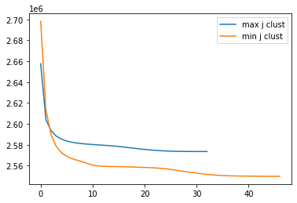

```python
plt.plot(t2_results[t2_max_j_clust_index][2][2:], label='max j clust')
plt.plot(t2_results[t2_min_j_clust_index][2][2:], label='min j clust')
plt.legend()
plt.show()
```

Similar to Test 1, the `j_clusts` vs number of iterations curves roughly follow logarithmic decaying paths. However, noticeably, the final `j_clust` values, in both the maximum and minimum cases, are larger than those in Test 1. This is reasonable because with fewer clusters, the average distance from data vectors to group representative vectors would be larger.

### Visualizing the K group representatives as images

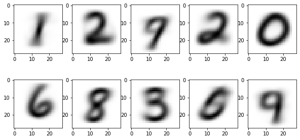

```python
fig, axs = plt.subplots(2, 5, figsize=(10, 5))
t2_max_j_clust_grvs = t2_results[t2_max_j_clust_index][1]

for i in range(2):
    for j in range(5):
        axs[i, j].imshow(t2_max_j_clust_grvs[i * 5 + j, :].reshape(28, 28), cmap='binary')
```

The images above show all 10 of the the group representatives from the run with the largest `j_clust` upon convergence. With 10 clusters for 10 digits, it is reasonable to think that each cluster would uniquely correspond to one of the 10 digits. However, the K-means algorithm seems to be paying more attention to some digits than others. For example, 0's and 1's are usually very prominent. Sometimes, each of them is represented by more than one group representatives although, notably, each would having different orientations. On the other hand, some 9's could be grouped with 7's while other 9's are grouped with 4's.

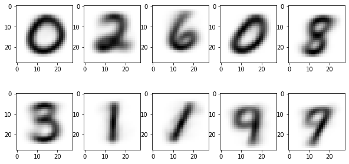

```python
fig, axs = plt.subplots(2, 5, figsize=(10, 5))
t2_min_j_clust_grvs = t2_results[t2_min_j_clust_index][1]

for i in range(2):
    for j in range(5):
        axs[i, j].imshow(t2_min_j_clust_grvs[i * 5 + j, :].reshape(28, 28), cmap='binary')
```

The images above show all 10 of the the group representatives from the run with the smallest `j_clust` upon convergence. Compared with the run with the largest `j_clust` upon convergence, my discoveries seem more obvious here. That is, there are two 0's and two 1's, each having different orientations. Some 9's are grouped with 4's while others are grouped with 7's. Otherwise, 2, 3, 6, and 8 seem to be well reconstructed. However, notably, 5 is missing from these group representatives.

### 10 nearest data points to each of the K group representatives

To evaluate the performance of `kmeans`, we want to understand how well each group representative represents its cluster. To do that, we pick 10 nearest data vectors around each group representative and manually record whether they are misclassified or not.

To conveniently compare each group representative with the 10 nearest data vectors around it, we display them as images side by side, creating an image grid. We distinguish group representatives from data vectors by setting the **group representatives to red-scale** and the **data vectors to gray-scale**.

In an image grid, each row starts with a group representative on the left, followed by 10 nearest data vectors around it. Below each image grid, a table mimicking the format of the image grid is manually created. To record the number of misclassified images for each group representative, one more column is added to the table.

Since we have 10 group representatives representing 10 clusters here, we pick 100 data vectors for the maximum `j_clust` case and 100 data vectors for the minimum `j_clust` case.

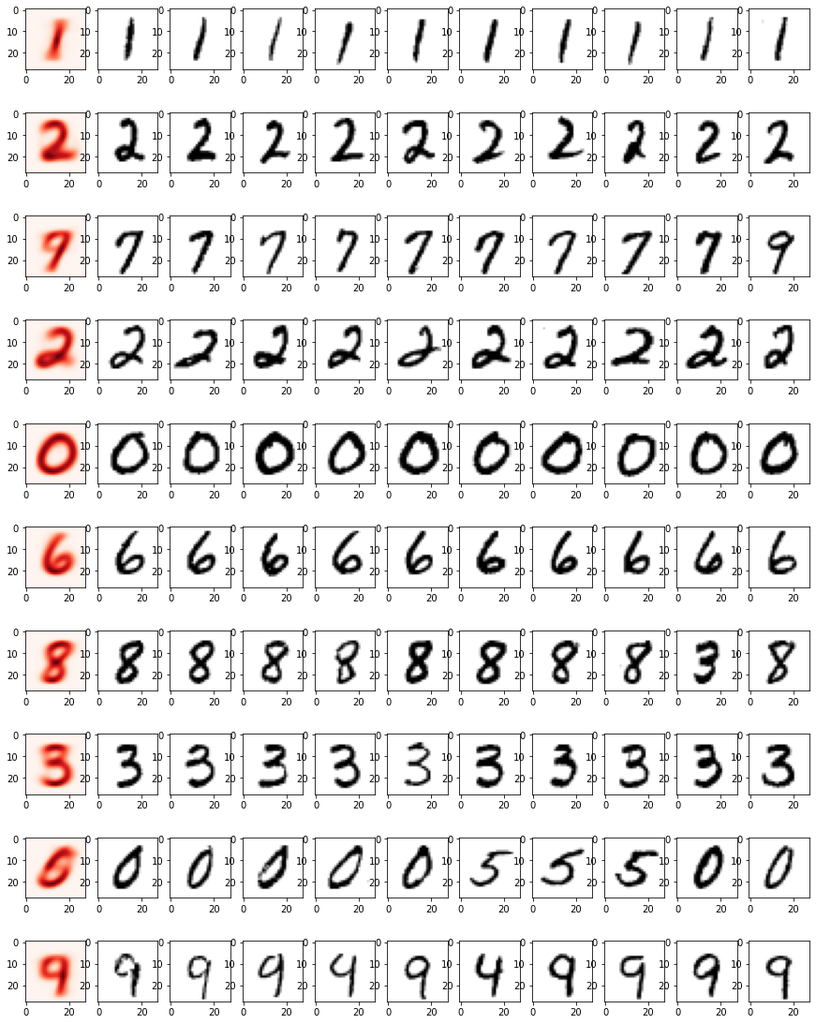

```python
fig, axs = plt.subplots(10, 11, figsize=(15, 20))

for i, grv in enumerate(t2_max_j_clust_grvs):
    axs[i, 0].imshow(grv.reshape(28, 28), cmap='Reds')

    ten_nearest_vectors = findTenNearest(train_x, grv)

    for j, nearest_vector in enumerate(ten_nearest_vectors):
        axs[i, j + 1].imshow(nearest_vector.reshape(28, 28), cmap='binary')
```

| GRVS | NDV1 | NDV2 | NDV3 | NDV4 | NDV5 | NDV6 | NDV7 | NDV8 | NDV9 | NDV10 | Misclassified count |
| --- | --- | --- | --- | --- | --- | --- | --- | --- | --- | --- | --- |
| 1 | 1 | 1 | 1 | 1 | 1 | 1 | 1 | 1 | 1 | 1 | 0 |
| 2 | 2 | 2 | 2 | 2 | 2 | 2 | 2 | 2 | 2 | 2 | 0 |
| 7 | 7 | 7 | 7 | 7 | 7 | 7 | 7 | 7 | 7 | 9 | 1 |
| 2 | 2 | 2 | 2 | 2 | 2 | 2 | 2 | 2 | 2 | 2 | 0 |
| 0 | 0 | 0 | 0 | 0 | 0 | 0 | 0 | 0 | 0 | 0 | 0 |
| 6 | 6 | 6 | 6 | 6 | 6 | 6 | 6 | 6 | 6 | 6 | 0 |
| 8 | 8 | 8 | 8 | 8 | 8 | 8 | 8 | 8 | 3 | 8 | 1 |
| 3 | 3 | 3 | 3 | 3 | 3 | 3 | 3 | 3 | 3 | 3 | 0 |
| 0 | 0 | 0 | 0 | 0 | 0 | 5 | 5 | 5 | 0 | 0 | 3 |
| 9 | 9 | 9 | 9 | 4 | 9 | 4 | 9 | 9 | 9 | 9 | 2 |

From the table above, we can calculate the error rate of the K = 10 run with the largest `j_clust` upon convergence to be **(1 + 1 + 3 + 2) / 100 = 7%**. This result is similar to the K = 20 run with the largest `j_clust` upon convergence.

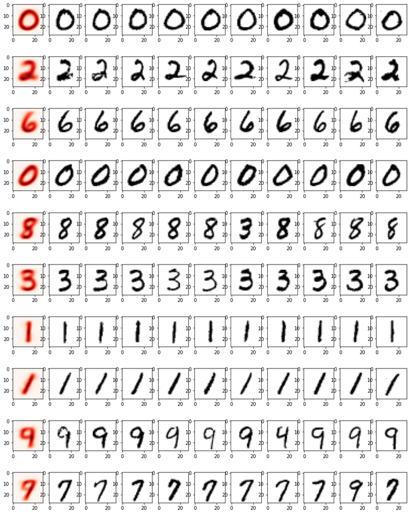

```python
fig, axs = plt.subplots(10, 11, figsize=(15, 20))

for i, grv in enumerate(t2_min_j_clust_grvs):
    axs[i, 0].imshow(grv.reshape(28, 28), cmap='Reds')

    ten_nearest_vectors = findTenNearest(train_x, grv)

    for j, nearest_vector in enumerate(ten_nearest_vectors):
        axs[i, j + 1].imshow(nearest_vector.reshape(28, 28), cmap='binary')
```

| GRVS | NDV1 | NDV2 | NDV3 | NDV4 | NDV5 | NDV6 | NDV7 | NDV8 | NDV9 | NDV10 | Misclassified count |
| --- | --- | --- | --- | --- | --- | --- | --- | --- | --- | --- | --- |
| 0 | 0 | 0 | 0 | 0 | 0 | 0 | 0 | 0 | 0 | 0 | 0 |
| 2 | 2 | 2 | 2 | 2 | 2 | 2 | 2 | 2 | 2 | 2 | 0 |
| 6 | 6 | 6 | 6 | 6 | 6 | 6 | 6 | 6 | 6 | 6 | 0 |
| 0 | 0 | 0 | 0 | 0 | 0 | 0 | 0 | 0 | 0 | 0 | 0 |
| 8 | 8 | 8 | 8 | 8 | 8 | 3 | 8 | 8 | 8 | 8 | 1 |
| 3 | 3 | 3 | 3 | 3 | 3 | 3 | 3 | 3 | 3 | 3 | 0 |
| 1 | 1 | 1 | 1 | 1 | 1 | 1 | 1 | 1 | 1 | 1 | 0 |
| 1 | 1 | 1 | 1 | 1 | 1 | 1 | 1 | 1 | 1 | 1 | 0 |
| 9 | 9 | 9 | 9 | 9 | 9 | 9 | 4 | 9 | 9 | 9 | 1 |
| 7 | 7 | 7 | 7 | 7 | 7 | 7 | 7 | 7 | 9 | 7 | 1 |

From the table above, we can calculate the error rate of the K = 10 run with the smallest `j_clust` upon convergence to be **(1 + 1 + 1) / 100 = 3%**. Because there is no potential conflict between my subjective understanding and the program's result of learning, this error rate seems reasonable as it is lower than that of the run with the largest `j_clust` upon convergence.

## Test 3: K = 5, P = 10

For the third test, `kmeans` is run 10 times, where each run clusters the data vectors into 5 clusters.

```python
K = 5
P = 10
start_time = time.time()
t3_results = []

with mpp.Pool(multiprocessing_pool_count) as pool:
    arguments = [(train_x, K) for i in range(P)]
    for result in tqdm.tqdm(pool.istarmap(kmeans, arguments), total=len(arguments)):
        t3_results.append(result)

print("--- %s seconds ---" % (time.time() - start_time))
```

```
--- 78.28710126876831 seconds ---
```

```python
## Find the indices of the two runs that produce the largest and smallest j_clust upon convergence
t3_max_j_clust_index, t3_min_j_clust_index = findMinMaxJclustIndices(t3_results)
```

### Plotting `j_clusts` as a function of the number of iterations

**Note:** The first two `j_clust` values for each run are not plotted because they are abnormally large due to `j_clust` being initialized to `float(sys.maxsize) / 2` in `kmeans`.

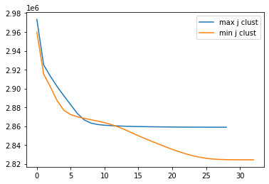

```python
plt.plot(t3_results[t3_max_j_clust_index][2][2:], label='max j clust')
plt.plot(t3_results[t3_min_j_clust_index][2][2:], label='min j clust')
plt.legend()
plt.show()
```

Compared to Test 1 and Test 2, the final `j_clust` values, in both the maximum and minimum cases, are larger. This is due to the number of clusters being further reduced. Also, the number of iterations it takes for `j_clust` to converge seems to have decreased in my multiple trials of running Test 3. However, this phenomenon is not always true.

### Visualizing the K group representatives as images

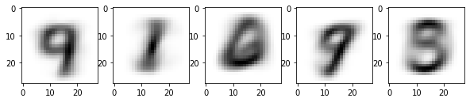

```python
## Image-grid function from:
##   https://matplotlib.org/3.1.0/gallery/subplots_axes_and_figures/subplots_demo.html
fig, axs = plt.subplots(1, 5, figsize=(10, 5))
t3_max_j_clust_grvs = t3_results[t3_max_j_clust_index][1]

for i in range(5):
    axs[i].imshow(t3_max_j_clust_grvs[i, :].reshape(28, 28), cmap='binary')
```

The 5 images above show the group representatives from the run with the largest `j_clust` upon convergence.

Since we have 10 hand-written digits but only 5 clusters, it is expected that the resulting group representatives would look like combinations of multiple digits. Within my multiple trials, exceptfor 0 and 1, other digits are often mixed together.

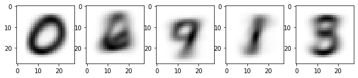

```python
fig, axs = plt.subplots(1, 5, figsize=(10, 5))
t3_min_j_clust_grvs = t3_results[t3_min_j_clust_index][1]

for i in range(5):
    axs[i].imshow(t3_min_j_clust_grvs[i, :].reshape(28, 28), cmap='binary')
```

The 5 images above show the group representatives from the run with the smallest `j_clust` upon convergence.

Theoretically, this would be a better result because `j_clust` is smaller. However, because everything are mostly mixed together, it is hard to tell if this result is better than that of the run with the largest `j_clust` upon convergence.

### 10 nearest data points to each of the K group representatives

To evaluate the performance of `kmeans`, we want to understand how well each group representative represents its cluster. To do that, we pick 10 nearest data vectors around each group representative and manually record whether they are misclassified or not.

To conveniently compare each group representative with the 10 nearest data vectors around it, we display them as images side by side, creating an image grid. We distinguish group representatives from data vectors by setting the **group representatives to red-scale** and the **data vectors to gray-scale**.

In an image grid, each row starts with a group representative on the left, followed by 10 nearest data vectors around it. Below each image grid, a table mimicking the format of the image grid is manually created. To record the number of misclassified images for each group representative, one more column is added to the table.

Since we have 5 group representatives representing 5 clusters here, we pick 50 data vectors for the maximum `j_clust` case and 50 data vectors for the minimum `j_clust` case.

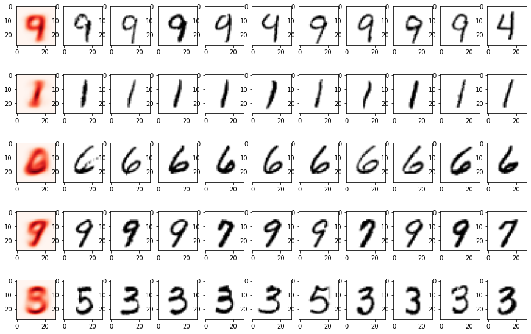

```python
fig, axs = plt.subplots(5, 11, figsize=(15, 10))

for i, grv in enumerate(t3_max_j_clust_grvs):
    axs[i, 0].imshow(grv.reshape(28, 28), cmap='Reds')

    ten_nearest_vectors = findTenNearest(train_x, grv)

    for j, nearest_vector in enumerate(ten_nearest_vectors):
        axs[i, j + 1].imshow(nearest_vector.reshape(28, 28), cmap='binary')
```

| GRVS | NDV1 | NDV2 | NDV3 | NDV4 | NDV5 | NDV6 | NDV7 | NDV8 | NDV9 | NDV10 | Misclassified count |
| --- | --- | --- | --- | --- | --- | --- | --- | --- | --- | --- | --- |
| 9 | 9 | 9 | 9 | 9 | 4 | 9 | 9 | 9 | 9 | 4 | 2 |
| 1 | 1 | 1 | 1 | 1 | 1 | 1 | 1 | 1 | 1 | 1 | 0 |
| 6 | 6 | 6 | 6 | 6 | 6 | 6 | 6 | 6 | 6 | 6 | 0 |
| 9 | 9 | 9 | 9 | 7 | 9 | 9 | 7 | 9 | 9 | 7 | 3 |
| 3 | 5 | 3 | 3 | 3 | 3 | 5 | 3 | 3 | 3 | 3 | 2 |

From the table above, we can calculate the error rate of the K = 5 run with the largest `j_clust` upon convergence to be **(2 + 3 + 2) / 50 = 14%**, which is higher than before. Since the group representatives are mixtures of various digits, it is reasonable that each of their corresponding nearest data vectors would be different digits as well.

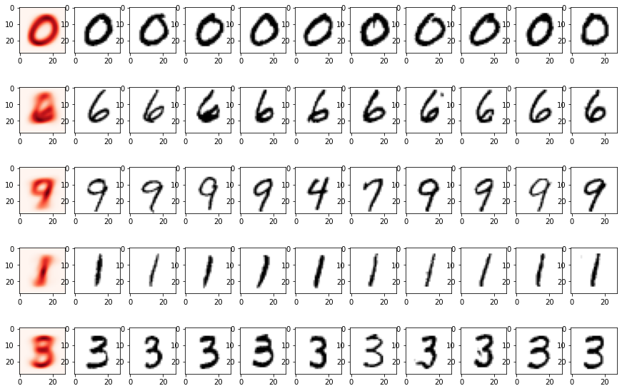

```python
fig, axs = plt.subplots(5, 11, figsize=(15, 10))

for i, grv in enumerate(t3_min_j_clust_grvs):
    axs[i, 0].imshow(grv.reshape(28, 28), cmap='Reds')

    ten_nearest_vectors = findTenNearest(train_x, grv)

    for j, nearest_vector in enumerate(ten_nearest_vectors):
        axs[i, j + 1].imshow(nearest_vector.reshape(28, 28), cmap='binary')
```

| GRVS | NDV1 | NDV2 | NDV3 | NDV4 | NDV5 | NDV6 | NDV7 | NDV8 | NDV9 | NDV10 | Misclassified count |
| --- | --- | --- | --- | --- | --- | --- | --- | --- | --- | --- | --- |
| 0 | 0 | 0 | 0 | 0 | 0 | 0 | 0 | 0 | 0 | 0 | 0 |
| 6 | 6 | 6 | 6 | 6 | 6 | 6 | 6 | 6 | 6 | 6 | 0 |
| 9 | 9 | 9 | 9 | 9 | 4 | 7 | 9 | 9 | 9 | 9 | 2 |
| 1 | 1 | 1 | 1 | 1 | 1 | 1 | 1 | 1 | 1 | 1 | 0 |
| 3 | 3 | 3 | 3 | 3 | 3 | 3 | 3 | 3 | 3 | 3 | 0 |

From the table above, we can calculate the error rate of the K = 5 run with the smallest `j_clust` upon convergence to be **2 / 50 = 4%**. This is significantly lower than that of the run with the largest `j_clust` upon convergence, which is reasonable. However, since we only have 50 data vectors for testing here, it is insufficient to assume this as the norm.

## Comparing K-means Clustering with Least Squares Classifiers

The two Least Squares Classifiers produced about 7% and 14% error rates, respectively, on both the training set and testing set, producing consistent performance. The error rates of the K-means algorithm vary for different number of clusters as well as different trials, which means its performance is not as consistent. Also, the K-means algorithm takes significantly longer time to run. However, because the two Least Squares Classifiers are supervised algorithms whereas K-means is unsupervised, comparing their error rates alone does not seem to tell the full story. To elaborate:

1) Least Squares Classifiers are trained on a set of features with corresponding labels. That is, answers are provided during their learning processes. So, during testing, if the answers follow the same logic, then their performance would be consistent. Also, they could be trained on a certain set of features and labels then be applied to a different set, such ability to generalize is not found on K-means.

2) K-means, on the other hand, is trained on a set of features with no labels. That is, no answers are provided during its learning process. It has to discover the answers that it thinks as the most reasonable. Those answers might deviate from the labels that are hidden from it, in which case the performance would take a hit. However, if the problem itself does not come with answers, then K-means is a good way to help find potential answers whereas Least Squares Classifiers would not know what to do if answers are not provided during the training process.

To summarize, if labels exist for the features, then Least Squares Classifiers are fast, consistent, and generalizable, whereas K-means is slow, inconsistent, and not generalizable. On the other hand, if labels do not exist for the features, then Least Squares Classifiers are not applicable, whereas K-means is able to find potential answers.